# STA 6133: Homework 1

Ricardo Cortez

2/7/2021

# 2.

On your computer, find a root fo the quadratic equation $ax^2+bx+c=0$ using the formula
$$x = \frac{-b+\sqrt{b^2-4ac}}{2a}$$

with the values $b = 1$ and $a = c= 10^{-n}$. Assess the accuracy of your answers for $n = 1, 5, 10$ by seeing how closely the equation is satisfied. Now think of a clever way to avoid subtractive cancellation and improve your answers.

## Solution:

Finding a root in a non-clever way:

```r
# create a quadratic function since we'll be testing several n's and potentially different b's
quad <- function(n,b){
  a <- 10^-n
  c <- a

  root_num_right <- sqrt(b^2-(4*a*c))
  #splitting the equations into separate terms to better understand the subtractive cancellation
  root_num <- -b +root_num_right
  root_den <- 2*a

  quad_root = root_num/root_den
  true_root = Re(polyroot(c(c,b,a)))[1] # only take the negative root since that's what we're dealing with


  #use Re to only take the real root of the complex number, checked them all, no imag parts.

  df <- data.frame("TrueRoot" =true_root, "QuadRoot" = quad_root)

  #calculate Relative Error
  rel_err <- abs((true_root-quad_root)/true_root)
  df$rel_err <- rel_err
  cat(paste0("Relative Error for a=",a, ", b=",b,", c=",c, ", and n=",n," is ", rel_err))

  return(df)
}

df1 = quad(1,1)
```

```
## Relative Error for a=0.1, b=1, c=0.1, and n=1 is 2.06063905221897e-15
```

```r
df2 = quad(5,1)
```

```
## Relative Error for a=1e-05, b=1, c=1e-05, and n=5 is 8.26403710463034e-08
```

```r
df3 = quad(10,1)
```

```
## Relative Error for a=1e-10, b=1, c=1e-10, and n=10 is 1
```

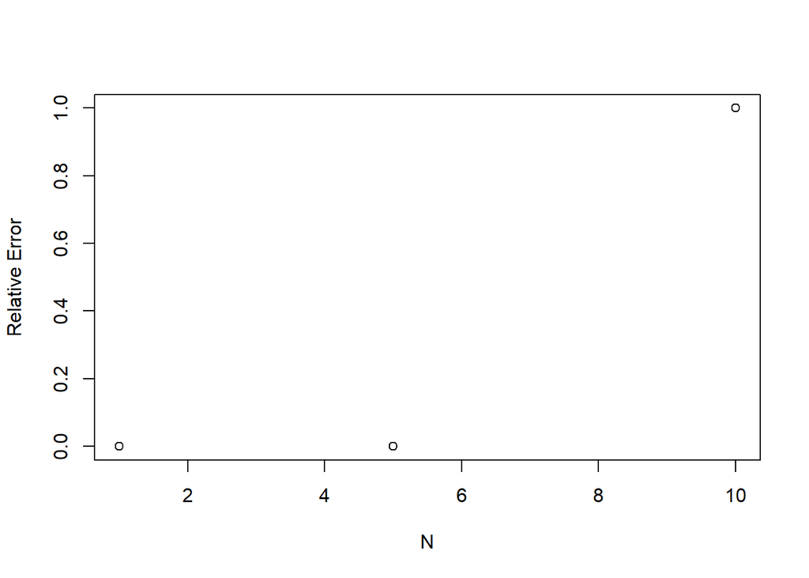

```r
plot(c(1,5,10),c(df1$rel_err,df2$rel_err,df3$rel_err), ylab = "Relative Error", xlab = "N")
```

From the plot above, we can see as n increases the relative error increases to 1, which indicates that subtractive cancellation is present. A closer observation of the individual terms (not shown) indicated that the most aggressive cancellation occurred in between the square root term and the $-b$ term. A common way of handling this type of cancellation is to use known mathematical identities to eliminate the need for subtraction between those elements. In this problem we used:
$$x^2-y^2 = (x-y)(x+y)$$

the derivation is as follows:

For Simplicity focus only on the numerator for now, the division element can be added later.
$$\sqrt{b^2-4ac} - b$$

let $z=\sqrt{b^2-4ac}$ and plug in the identity:
$$\frac{(z-b)(z+b)}{z+b}=\frac{z^2-b^2}{z+b}$$

Plugging original values back in:
$$\frac{b^2-4ac-b^2}{\sqrt{b^2-4ac}+b}$$
Simplification results:
$$\frac{-4ac}{\sqrt{b^2-4ac}+b}$$
Adding back the original denominator:
$$\frac{-4ac}{2a*(\sqrt{b^2-4ac}+b)}$$
Simplify again and obtain the final equation:
$$\frac{-2c}{(\sqrt{b^2-4ac}+b)}$$

Modifying the earlier code:

```r
quad_new <- function(n,b){
  a <- 10^-n
  c <- a

  quad_root = -2*c / (sqrt(b^2 - 4*a*c) + b)
  true_root = Re(polyroot(c(c,b,a)))[1] # only take the negative root since that's what we're dealing with


  #use Re to only take the real root of the complex number, checked them all, no imag parts.

  df <- data.frame("TrueRoot" =true_root, "QuadRoot" = quad_root)

  #calculate Relative Error
  rel_err <- abs((true_root-quad_root)/true_root)
  df$rel_err <- rel_err
  cat(paste0("Relative Error for a=",a, ", b=",b,", c=",c, ", and n=",n," is ", rel_err))

  return(df)
}

df1_new <- quad_new(1,1)
```

```
## Relative Error for a=0.1, b=1, c=0.1, and n=1 is 0
```

```r
df2_new <-quad_new(5,1)
```

```
## Relative Error for a=1e-05, b=1, c=1e-05, and n=5 is 1.69406589433919e-16
```

```r
df3_new <-quad_new(10,1)
```

```
## Relative Error for a=1e-10, b=1, c=1e-10, and n=10 is 1.29246970711411e-16
```

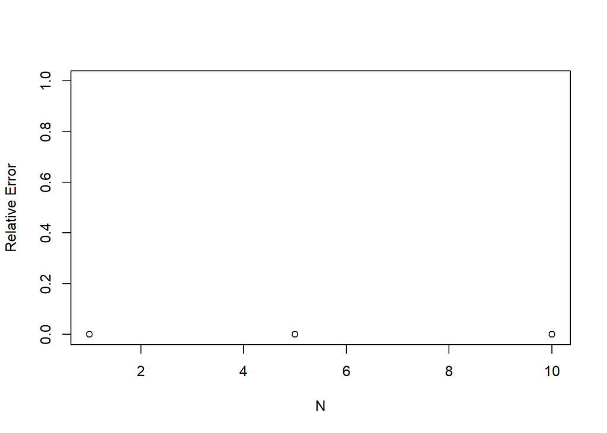

```r
plot(c(1,5,10),c(df1_new$rel_err,df2_new$rel_err,df3_new$rel_err), ylab = "Relative Error", xlab = "N",ylim = c(0,1))
```

Using the new solution provides a better estimate of the roots when subtractive cancellation is present in the original equation, it is clear to see in the plot above that the relative error stays near 0 for all N’s.

# 3

The following data are an i.i.d. sample from the $Cauchy(\theta , 1)$ distribution:
$$\begin{array}
{rrr}
1.77 & -0.23 & 2.76 & 3.80 & 3.47 & 56.75 \\
-1.34 & 4.24 & -2.44 & 3.29 & 3.71 & -2.40 & \\
4.53 & -0.07 & -1.05 & -13.87 & -2.53 & -1.75 \\
0.27 & 43.21
\end{array}$$

## a

Plot the log–likelihood function. Then find the MLE of θ using Newton’s method. Try all the following starting values: −11, −1, 0, 1.5, 4, 4.7, 7, 38. Discuss your results. Is the sample mean a good starting point?

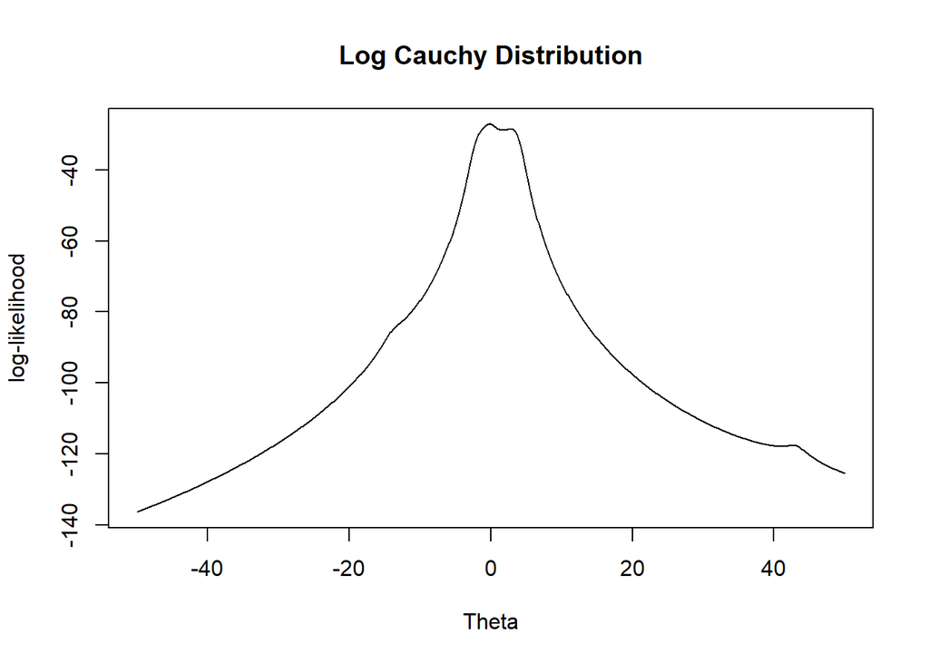

```r
#Import the data
data <- c(1.77, -0.23, 2.76, 3.80, 3.47, 56.75, -1.34, 4.24, -2.44, 3.29,
          3.71, -2.40, 4.53, -0.07, -1.05, -13.87, -2.53, -1.75, 0.27, 43.21)

n <- length(data)

#log likelihood cauchy function
log_cauchy <- function(theta){
  return(n*log(pi)-sum(log(1+(data-theta)^2)))
}
#first derivative of the log-likelihood
log_cauchy_prime <- function(theta){
return(sum(2*(data-theta)/(1+(data-theta)^2)))
}

#second derivative of the log-likelihood
log_cauchy_2prime <- function(theta){
  return(sum(2*(-1+(data-theta)^2) / (1+(data-theta)^2)^2))
}

#function for log-cauchy and log-cauchy prime
cauchy <- function(theta){
  return(c(log_cauchy(theta),
           log_cauchy_prime(theta)))
}
#function for log-cauchy prime and 2nd prime of log-cauchy
cauchy_primes <-function(theta){
  return(c(log_cauchy_prime(theta),log_cauchy_2prime(theta)))
}

theta_list <- seq(-50,50,.1)
values = sapply(theta_list, cauchy)

log_cauchy_values <- values[1,]
log_cauchy_prime_values <- values[2,]

plot(theta_list,log_cauchy_values, type = "l", main = "Log Cauchy Distribution",xlab = "Theta", ylab = "log-likelihood")
```

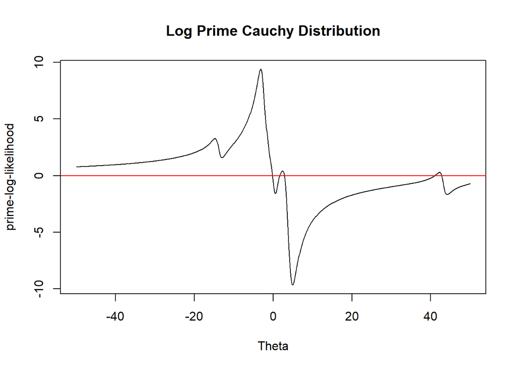

```r
plot(theta_list,log_cauchy_prime_values, type = "l", main= "Log Prime Cauchy Distribution", xlab = "Theta", ylab = "prime-log-likelihood")
abline(h = 0, col = "red")
```

```r
# Newton's Method function provided by Dr. DeOliveira
newtonraphson <- function(ftn, x0, tol = 1e-9, max.iter = 100) {
  ## Newton_Raphson algorithm for solving ftn(x)[1] == 0
  ## It is assumed that ftn is a function of a single variable that returns
  ## the function value and its first derivative as a vector of length 2.
  ## x0 is the initial guess of the root.
  ## The algorithm terminates when the function value is within distance tol of 0,
  ## or the number of iterations exceeds max.iter, whichever happens first
  # initialise
  x <- x0
  fx <- ftn(x)
  iter <-  0
  # continue iterating until stopping conditions are met
  while ((abs(fx[1]) > tol) & (iter < max.iter)) {
    x <- x - fx[1]/fx[2]
    fx <- ftn(x)
    iter<- iter+1
    #cat("At iteration", iter, "value of x is:", x, "\n")
  }
  # output depends on success of algorithm
  if (abs(fx[1]) > tol) {
    #cat("Algorithm failed to converge\n")
    return(NULL)
  } else {
    #cat("Algorithm converged\n")
    return(c(root = x, f.val = fx[1]))
  }
}

mle_values <- roots <- test_values <- c(-11,-1,0,1.5,4,4.7,7,38, mean(data))

for(i in 0:length(test_values)){
  root = newtonraphson(cauchy_primes,test_values[i])[1]
  roots[i] = root
  mle_values[i] = log_cauchy(root)
}
roots
```

```
## [1] -5.381711e+10 -1.922866e-01 -1.922866e-01  1.713587e+00  2.817472e+00
## [6] -1.922866e-01  4.104085e+01  4.279538e+01  5.487662e+01
```

```r
 ### max value is at -1
cat(paste0("The MLE is ",test_values[which.max(mle_values)]))
```

```
## The MLE is -1
```

Utilizing different starting points resulted in getting several different root values, which given the execution pattern of the newton-raphson algorithm and the log-prime cauch distribution plot above would be expected. Using the sample mean for a cauchy distribution is not very advantageous on it’s own because the cauchy distribution does not have a population mean. It did not show any benefits to using that over any of the other points.